# Devoir Maison ACP sur des donnees de temperature

MOUHAMADOU KANE

2022-11-16

On va charger nos donnees pour ensuite repondre aux questions

```
##           Janv Fev Mars  Avr  Mai Juin juil Aout Sept  Oct  Nov Dec   Lat  Long
## Bordeaux   5.6 6.6 10.3 12.8 15.8 19.3 20.9 21.0 18.6 13.8  9.1 6.2 44.50 -0.34
## Brest      6.1 5.8  7.8  9.2 11.6 14.4 15.6 16.0 14.7 12.0  9.0 7.0 48.24 -4.29
## Clermont   2.6 3.7  7.5 10.3 13.8 17.3 19.4 19.1 16.2 11.2  6.6 3.6 45.47  3.05
## Grenoble   1.5 3.2  7.7 10.6 14.5 17.8 20.1 19.5 16.7 11.4  6.5 2.3 45.10  5.43
## Lille      2.4 2.9  6.0  8.9 12.4 15.3 17.1 17.1 14.7 10.4  6.1 3.5 50.38  3.04
## Lyon       2.1 3.3  7.7 10.9 14.9 18.5 20.7 20.1 16.9 11.4  6.7 3.1 45.45  4.51
## Marseille  5.5 6.6 10.0 13.0 16.8 20.8 23.3 22.8 19.9 15.0 10.2 6.9 43.18  5.24
## Montpell   5.6 6.7  9.9 12.8 16.2 20.1 22.7 22.3 19.3 14.6 10.0 6.5 43.36  3.53
## Nantes     5.0 5.3  8.4 10.8 13.9 17.2 18.8 18.6 16.4 12.2  8.2 5.5 47.13 -1.33
## Nice       7.5 8.5 10.8 13.3 16.7 20.1 22.7 22.5 20.3 16.0 11.5 8.2 43.42  7.15
## Paris      3.4 4.1  7.6 10.7 14.3 17.5 19.1 18.7 16.0 11.4  7.1 4.3 48.52  2.20
## Rennes     4.8 5.3  7.9 10.1 13.1 16.2 17.9 17.8 15.7 11.6  7.8 5.4 48.05 -1.41
## Strasbo    0.4 1.5  5.6  9.8 14.0 17.2 19.0 18.3 15.1  9.5  4.9 1.3 48.35  7.45
## Toulouse   4.7 5.6  9.2 11.6 14.9 18.7 20.9 20.9 18.3 13.3  8.6 5.5 43.36  1.26
## Vichy      2.4 3.4  7.1  9.9 13.6 17.1 19.3 18.8 16.0 11.0  6.6 3.4 46.08  3.26
##             Moy Ampl
## Bordeaux  13.33 15.4
## Brest     10.77 10.2
## Clermont  10.94 16.8
## Grenoble  10.98 18.6
## Lille      9.73 14.7
## Lyon      11.36 18.6
## Marseille 14.23 17.8
## Montpell  13.89 17.1
## Nantes    11.69 13.8
## Nice      14.84 15.2
## Paris     11.18 15.7
## Rennes    11.13 13.1
## Strasbo    9.72 18.6
## Toulouse  12.68 16.2
## Vichy     10.72 16.9
```

## 1- Analyse Descriptives des variables :

|  | Janv | Fev | Mars | Avr | Mai | Juin | juil | Aout | Sept | Oct | Nov | Dec | Lat | Long | Moy | Ampl |
| --- | --- | --- | --- | --- | --- | --- | --- | --- | --- | --- | --- | --- | --- | --- | --- | --- |
|  | Min. :0.400 | Min. :1.500 | Min. : 5.600 | Min. : 8.90 | Min. :11.60 | Min. :14.40 | Min. :15.60 | Min. :16.00 | Min. :14.70 | Min. : 9.50 | Min. : 4.900 | Min. :1.300 | Min. :43.18 | Min. :-4.290 | Min. : 9.72 | Min. :10.20 |
|  | 1st Qu.:2.400 | 1st Qu.:3.350 | 1st Qu.: 7.550 | 1st Qu.:10.00 | 1st Qu.:13.70 | 1st Qu.:17.15 | 1st Qu.:18.90 | 1st Qu.:18.45 | 1st Qu.:15.85 | 1st Qu.:11.30 | 1st Qu.: 6.600 | 1st Qu.:3.450 | 1st Qu.:43.96 | 1st Qu.: 0.460 | 1st Qu.:10.86 | 1st Qu.:14.95 |
|  | Median :4.700 | Median :5.300 | Median : 7.800 | Median :10.70 | Median :14.30 | Median :17.50 | Median :19.40 | Median :19.10 | Median :16.40 | Median :11.60 | Median : 7.800 | Median :5.400 | Median :45.47 | Median : 3.050 | Median :11.18 | Median :16.20 |
|  | Mean :3.973 | Mean :4.833 | Mean : 8.233 | Mean :10.98 | Mean :14.43 | Mean :17.83 | Mean :19.83 | Mean :19.57 | Mean :16.99 | Mean :12.32 | Mean : 7.927 | Mean :4.847 | Mean :46.04 | Mean : 2.583 | Mean :11.81 | Mean :15.91 |
|  | 3rd Qu.:5.550 | 3rd Qu.:6.200 | 3rd Qu.: 9.550 | 3rd Qu.:12.20 | 3rd Qu.:15.35 | 3rd Qu.:19.00 | 3rd Qu.:20.90 | 3rd Qu.:20.95 | 3rd Qu.:18.45 | 3rd Qu.:13.55 | 3rd Qu.: 9.050 | 3rd Qu.:6.350 | 3rd Qu.:48.15 | 3rd Qu.: 4.875 | 3rd Qu.:13.01 | 3rd Qu.:17.45 |
|  | Max. :7.500 | Max. :8.500 | Max. :10.800 | Max. :13.30 | Max. :16.80 | Max. :20.80 | Max. :23.30 | Max. :22.80 | Max. :20.30 | Max. :16.00 | Max. :11.500 | Max. :8.200 | Max. :50.38 | Max. : 7.450 | Max. :14.84 | Max. :18.60 |

Dans cette partie on se focalise uniquement sur les 12 mois :

**- Janvier :** La temperature minimale est de **0.40** et **7.5** est la temperature maximale ; On voit aussi **50%** des villes on une temperature **< ou egale 4.7** et **50%** des villes on une temperature **> ou egale 4.7**. ET **25%** des villes on une temperature **< ou egale 2.4** par contre **75%** des villes on une temperature **< ou egale a 5.55**.

**- Mars :** La temperature minimale est de **5.600** et **10.800** est la temperature maximale ; On voit aussi **50%** des villes on une temperature **< 7.800** et **50%** des villes on une temperature **> 7.800**. ET **25%** des villes on une temperature **< 7.550** par contre **75%** des villes on une temperature **< ou egale a 9.550**.

**- Mai :** La temperature minimale est de **11.60** et **16.80** est la temperature maximale ; On voit aussi **50%** des villes on une temperature **< 14.30** et **50%** des villes on une temperature **> ou egale a 14.30**. ET **25%** des villes on une temperature **< 13.70** par contre **75%** des villes on une temperature **< ou egale a 15.35**.

**- Juin :** La temperature minimale est de **14.40** et **20.80** est la temperature maximale ; On voit aussi **50%** des villes on une temperature **< 17.50** et **50%** des villes on une temperature **> 17.50**. ET **25%** des villes on une temperature **< 17.15** par contre **75%** des villes on une temperature **=19.00**.

**- Juillet :** La temperature minimale est de **15.60** et **23.30** est la temperature maximale ; On voit aussi **50%** des villes on une temperature moyenne < **19.40** et **50%** des villes on une temperature moyenne > **19.40**. ET **25%** des villes on une temperature **< 18.90** par contre **75%** des villes on une temperature moyenne **< ou egale a 20.90**.

**- Aout :** La temperature moyenne minimale est de **16.00** et **22.80** est la temperature maximale ; On voit aussi **50%** des villes on une temperature moyenne < **19.10** et **50%** des villes on une temperature moyenne > **19.10**. ET **25%** des villes on une temperature moyenne **< 18.45** par contre **75%** des villes on une temperature moyenne **< ou egale a 20.95**.

**- Septembre :** La temperature moyenne minimale est de **14.70** et **20.30** est la temperature maximale ; On voit aussi **50%** des villes on une temperature moyenne < **16.40** et **50%** des villes on une temperature moyenne > **16.40**. ET **25%** des villes on une temperature moyenne **< 15.85** par contre **75%** des villes on une temperature moyenne **< ou egale a 18.45**.

**- Otobre :** La temperature moyenne minimale est de **9.50** et **16.00** est la temperature maximale ; On voit aussi **50%** des villes on une temperature moyenne **< 11.60** et **50%** des villes on une temperature moyenne > **11.60**. ET **25%** des villes on une temperature moyenne **< 11.30** par contre **75%** des villes on une temperature moyenne **< ou egale a 13.55**.

**- Novembre :** La temperature moyenne minimale est de **4.900** et **11.500** est la temperature maximale ; On voit aussi **50%** des villes on une temperature moyenne < **7.800** et **50%** des villes on une temperature moyenne > **7.800**. ET **25%** des villes on une temperature moyenne **< 6.600** par contre **75%** des villes on une temperature moyenne **< ou egale a 9.050**.

Ensuite interpretons la matrice de **correllation** de nos 12 mois. Pour ce faire utilisons la fonction **corrplot** de la librairie *corrplot* permet de représenter graphiquement une matrice de corrélation.

|  | Janv | Fev | Mars | Avr | Mai | Juin | juil | Aout | Sept | Oct | Nov | Dec |
| --- | --- | --- | --- | --- | --- | --- | --- | --- | --- | --- | --- | --- |
| Janv | 1.0000000 | 0.9734704 | 0.8353014 | 0.6114770 | 0.3626412 | 0.3389457 | 0.2969079 | 0.4051325 | 0.6037179 | 0.8504937 | 0.9509037 | 0.9938593 |
| Fev | 0.9734704 | 1.0000000 | 0.9311453 | 0.7611773 | 0.5466228 | 0.5244341 | 0.4902894 | 0.5880152 | 0.7597188 | 0.9402876 | 0.9861091 | 0.9700965 |
| Mars | 0.8353014 | 0.9311453 | 1.0000000 | 0.9195281 | 0.7666562 | 0.7567175 | 0.7215285 | 0.7981404 | 0.9106181 | 0.9684783 | 0.9273160 | 0.8335550 |
| Avr | 0.6114770 | 0.7611773 | 0.9195281 | 1.0000000 | 0.9526127 | 0.9421577 | 0.9122837 | 0.9490019 | 0.9784065 | 0.9053328 | 0.7819685 | 0.6193040 |
| Mai | 0.3626412 | 0.5466228 | 0.7666562 | 0.9526127 | 1.0000000 | 0.9937607 | 0.9812381 | 0.9803087 | 0.9421352 | 0.7702184 | 0.5910447 | 0.3807358 |
| Juin | 0.3389457 | 0.5244341 | 0.7567175 | 0.9421577 | 0.9937607 | 1.0000000 | 0.9915370 | 0.9886671 | 0.9403550 | 0.7567028 | 0.5724514 | 0.3612955 |
| juil | 0.2969079 | 0.4902894 | 0.7215285 | 0.9122837 | 0.9812381 | 0.9915370 | 1.0000000 | 0.9906462 | 0.9328902 | 0.7386823 | 0.5471737 | 0.3239003 |
| Aout | 0.4051325 | 0.5880152 | 0.7981404 | 0.9490019 | 0.9803087 | 0.9886671 | 0.9906462 | 1.0000000 | 0.9701480 | 0.8120776 | 0.6365820 | 0.4302224 |
| Sept | 0.6037179 | 0.7597188 | 0.9106181 | 0.9784065 | 0.9421352 | 0.9403550 | 0.9328902 | 0.9701480 | 1.0000000 | 0.9255652 | 0.7961364 | 0.6224199 |
| Oct | 0.8504937 | 0.9402876 | 0.9684783 | 0.9053328 | 0.7702184 | 0.7567028 | 0.7386823 | 0.8120776 | 0.9255652 | 1.0000000 | 0.9642981 | 0.8656875 |
| Nov | 0.9509037 | 0.9861091 | 0.9273160 | 0.7819685 | 0.5910447 | 0.5724514 | 0.5471737 | 0.6365820 | 0.7961364 | 0.9642981 | 1.0000000 | 0.9608846 |
| Dec | 0.9938593 | 0.9700965 | 0.8335550 | 0.6193040 | 0.3807358 | 0.3612955 | 0.3239003 | 0.4302224 | 0.6224199 | 0.8656875 | 0.9608846 | 1.0000000 |

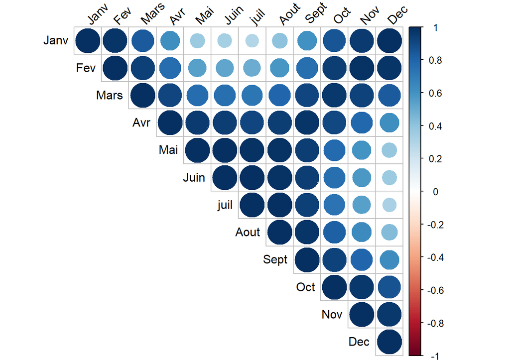

**-Fevrier** est **fortement positement** correlle avec **Mars,Septembre, Octobre, Novembre et Decembre** mais aussi on note une correllation **faible** avec les mois **Mai, Juin et Aout**.

**- Juin** est **fortement positement** correlle avec **Juin, Juillet, Aout,Septembre et Octobre** mais aussi on note une correllation **faible** avec le mois **Novembre**.

**- Juillet** est **fortement positement** correlle avec **Aout,Septembre et Octobre** mais aussi on note une correllation **faible** avec le mois **Novembre**.

**- Aout** est **fortement positement** correlle avec **Septembre et Octobre** mais aussi on note une correllation **faible** avec le mois **Novembre**.

**- Septembre** est **fortement positement** correlle avec **Octobre, Novembre et Decembre** .

**- Octobre** est **fortement positement** correlle avec **, Novembre et Decembre** .

**- Nvembre** est **fortement positement** correlle avec **Decembre** .

Au vue des correllations qu’on a vue avec certaines variables, cela peut nous permettre de faire un **ACP** pour reduire les dimensions.

Faisons aussi le **Boxplot** pour voir la dispersion de non 12 variables

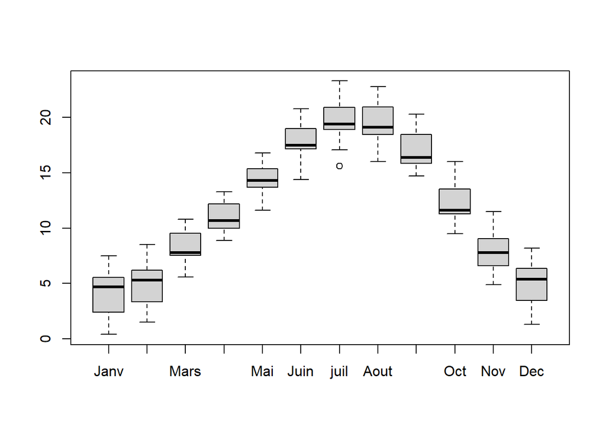

On voit que toutes nos variables sont presque homogenes donc on peut faire un **ACP non normee ou un ACP normee**. On choisira dans la suite de faire un **un ACP normee**.

# 2. Quelle est l’inertie associée au premier axe factoriel? Au second axe? Quelle est l’inertie totale? Quel est le pourcentage d’inertie associé au premier plan factoriel?

```
## **Results for the Principal Component Analysis (PCA)**
## The analysis was performed on 15 individuals, described by 12 variables
## *The results are available in the following objects:
##
##    name               description
## 1  "$eig"             "eigenvalues"
## 2  "$var"             "results for the variables"
## 3  "$var$coord"       "coord. for the variables"
## 4  "$var$cor"         "correlations variables - dimensions"
## 5  "$var$cos2"        "cos2 for the variables"
## 6  "$var$contrib"     "contributions of the variables"
## 7  "$ind"             "results for the individuals"
## 8  "$ind$coord"       "coord. for the individuals"
## 9  "$ind$cos2"        "cos2 for the individuals"
## 10 "$ind$contrib"     "contributions of the individuals"
## 11 "$call"            "summary statistics"
## 12 "$call$centre"     "mean of the variables"
## 13 "$call$ecart.type" "standard error of the variables"
## 14 "$call$row.w"      "weights for the individuals"
## 15 "$call$col.w"      "weights for the variables"
```

Linertie associer au premier axe est de **9.58178**

```
## [1] 9.58178
```

Linertie associer au deuxieme axe est de **2.276418**

```
## [1] 2.276418
```

L’inertie totale est : **12**

```
## [1] 12
```

Le pourcentage d’inertie au premier plan factoriel est de :**98.81832**.

```
## [1] 98.81832
```

# 3. Représenter à l’aide de diagrammes en bâtons l’inertie des axes (“éboulis des valeurspropres”) et le pourcentage d’inertie cumulé.

Faisons la representation de diagrammes en bâtons l’inertie des axes :

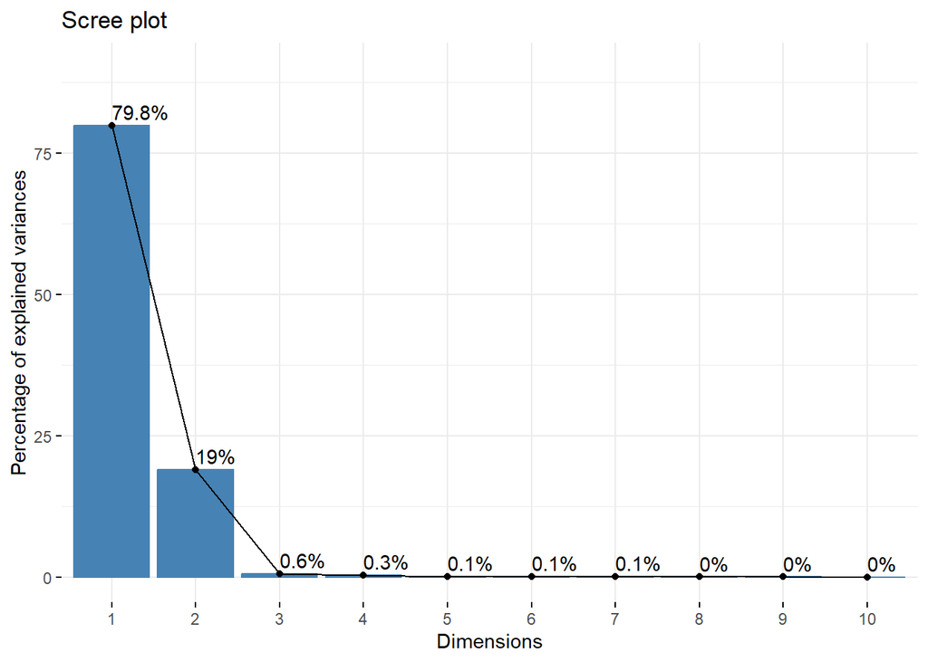

# 4. Produire les corrélations des variables avec l’axe 1 et les trier de façon décroissante.Même chose pour l’axe 2. Quelle est la variable la plus corrélée à l’axe 1 ? à l’axe 2?

**- Pour l’axe 1 :**

On affiche d’abord les correlation :

```
##      Janv       Fev      Mars       Avr       Mai      Juin      juil      Aout
## 0.7612384 0.8804578 0.9687704 0.9693357 0.8727646 0.8635747 0.8415346 0.8986059
##      Sept       Oct       Nov       Dec
## 0.9740289 0.9801599 0.9037531 0.7743349
```

On va ensuite afficher le triage de façon décroissante

```
##       Oct      Sept       Avr      Mars       Nov      Aout       Fev       Mai
## 0.9801599 0.9740289 0.9693357 0.9687704 0.9037531 0.8986059 0.8804578 0.8727646
##      Juin      juil       Dec      Janv
## 0.8635747 0.8415346 0.7743349 0.7612384
```

Donc on voit **Octobre** est la plus correlle a l’axe 1

**- Pour l’axe 2 :**

On affiche d’abord les correlation :

```
##       Janv        Fev       Mars        Avr        Mai       Juin       juil
##  0.6443379  0.4690786  0.1560084 -0.2036737 -0.4747092 -0.4993460 -0.5314197
##       Aout       Sept        Oct        Nov        Dec
## -0.4299386 -0.2081014  0.1704565  0.4139260  0.6242957
```

On va ensuite afficher le triage de façon décroissante

```
##       Janv        Dec        Fev        Nov        Oct       Mars        Avr
##  0.6443379  0.6242957  0.4690786  0.4139260  0.1704565  0.1560084 -0.2036737
##       Sept       Aout        Mai       Juin       juil
## -0.2081014 -0.4299386 -0.4747092 -0.4993460 -0.5314197
```

Donc on voit **Janvier** est la plus correlle a l’axe 2

# 5. Retrouver par le calcul la contribution de la variable la plus corrélée avec l’axe 1.

Pour repondre a la question on va d’abord afficher la contribution avec la fonction **PCA** et ensuite comparer au resultat par calcul

```
##      Janv       Fev      Mars       Avr       Mai      Juin      juil      Aout
##  6.047768  8.090417  9.794799  9.806233  7.949651  7.783119  7.390907  8.427376
##      Sept       Oct       Nov       Dec
##  9.901420 10.026461  8.524196  6.257653
```

On voit que la contribution de la variable **Octobre** est de **10.026461**.

Par calcule on cherche d’abord le maximum de cordonne a l’axe 1 pour l’eleve au carree est ensuite le divise a la valeur propre de l’axe 1

```
## [1] 10.02646
```

On a retrouver la valeur par calcule.

# 6. Quel est l’individu dont la qualité de représentation sur le plan (1, 2) est la plus élevée? la moins élevé?

Pour ce faire on va utiliser la **fviz_cos2** pour afficher par ordre decroissant

```
##                Dim.1       Dim.2
## Bordeaux  0.94668773 0.001161224
## Brest     0.23436246 0.763393814
## Clermont  0.87988441 0.103705112
## Grenoble  0.42894041 0.522580994
## Lille     0.97152116 0.019355705
## Lyon      0.17813711 0.817127272
## Marseille 0.96419529 0.028358560
## Montpell  0.98575843 0.010862202
## Nantes    0.05645333 0.886324192
## Nice      0.98005143 0.016920844
## Paris     0.88935998 0.014094539
## Rennes    0.41985296 0.566502170
## Strasbo   0.77565410 0.217137845
## Toulouse  0.95255524 0.005855863
## Vichy     0.92150642 0.062910418
```

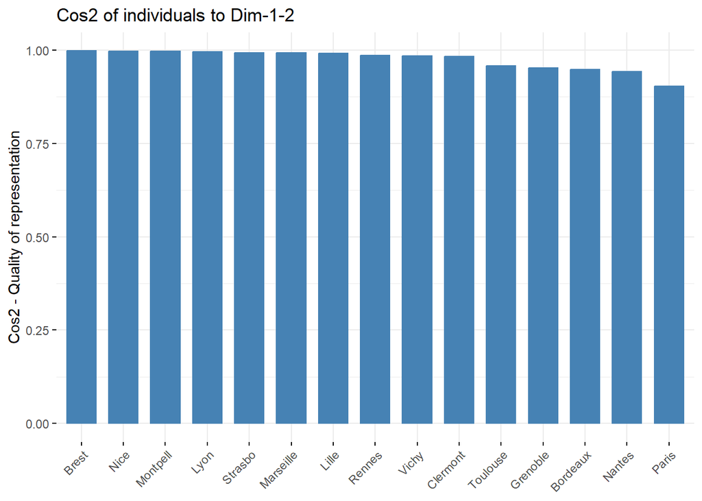

On voit que sur le plan (1,2) **Brest** est le mieux represente parcontre **Paris** est le moins represente.

# 7. Quel est l’individu ayant le plus contribué à la formation de l’axe 1? le moins contribué? Donner les contributions significatives des individus à l’axe 1.

```
##       Nice  Marseille      Lille   Montpell    Strasbo   Bordeaux      Brest
## 25.1063100 16.2497301 12.3718247 11.9672370 11.7277788  6.7759249  3.5789091
##      Vichy   Toulouse   Clermont   Grenoble     Rennes      Paris       Lyon
##  3.3720591  2.0972252  2.0725832  1.6271372  1.4400400  1.0731542  0.4850349
##     Nantes
##  0.0550515
```

On vois **Nice** est l’indiviuds qui a le plus contribue a la formation de l’axe 1.

Parcontre **Nantes** est l’indiviuds qui a le moin contribue a la formation de l’axe 1.

Pour les contributions significatives des individus à l’axe 1 on va utiliser la **fviz_contrib** :

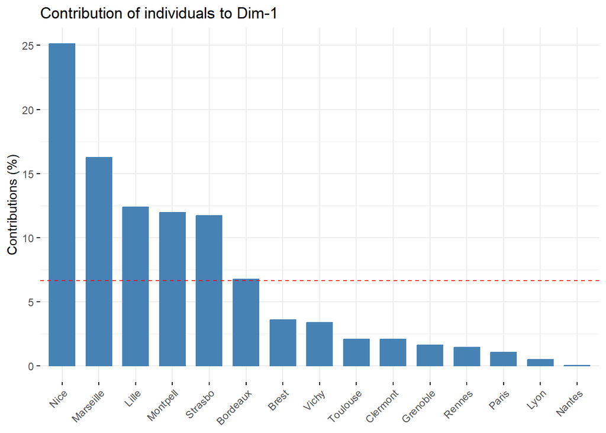

On voit les individus Nice,Marseille,Lille,Montpellier,Strasbourg et Bordeaux sont les plus significatifs car ils sont au dessus de la ligne **rouge**.

# 8. Quel est l’individu ayant le plus contribué à la formation de l’axe 2? le moins contribué. Donner les contributions significatives des individus à l’axe 2.

```
##       Brest     Strasbo        Lyon    Grenoble      Rennes      Nantes
## 49.06878939 13.81902127  9.36488350  8.34401167  8.17848800  3.63802974
##   Marseille        Nice       Lille    Clermont       Vichy    Montpell
##  2.01168233  1.82452633  1.03749158  1.02820712  0.96897702  0.55505413
##       Paris    Toulouse    Bordeaux
##  0.07158624  0.05426751  0.03498418
```

On vois **Brest** est l’indiviuds qui a le plus contribue a la formation de l’axe 2.

Parcontre **Bordeaux** est l’indiviuds qui a le moin contribue a la formation de l’axe 2.

Pour les contributions significatives des individus à l’axe 2 on va utiliser la **fviz_contrib** :

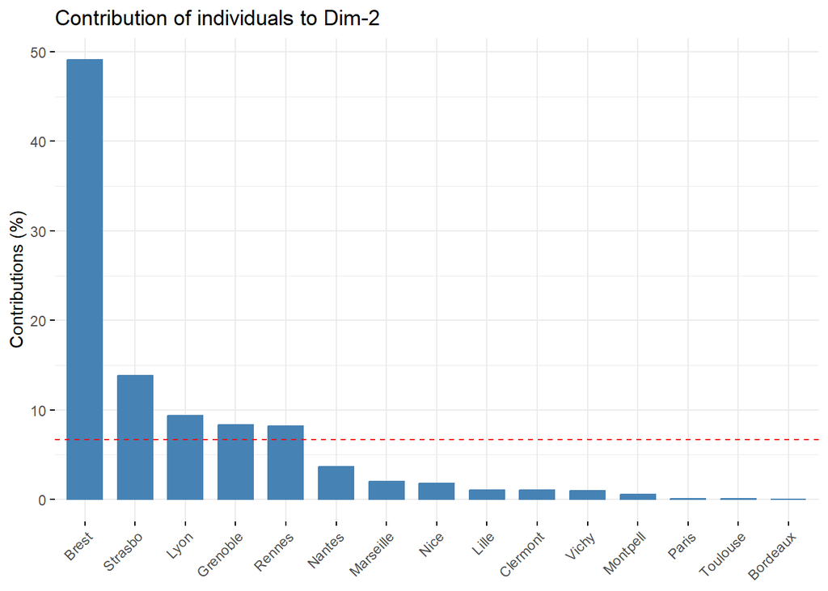

On voit les individus Brest,Strasbourg,Lyon,Grenoble et Rennes sont les plus significatifs car ils sont au-dessus de la ligne **rouge**.

# 9. Trier les individus du plus éloigné au plus proche du centre de gravité du nuage.

Pour ce faire on va utiliser la methode de calcule et ensuite utiliser la fonction de **dist** pour comparer les resultats.

**- Methodes calcule directe :**

```
##      Nice Marseille     Brest   Strasbo     Lille  Montpell  Bordeaux  Grenoble
##  6.058670  4.903276  4.679638  4.644850  4.258624  4.170089  3.122620  2.277674
##     Vichy    Rennes      Lyon  Clermont  Toulouse     Paris    Nantes
##  2.275394  2.205078  1.973546  1.824815  1.741494  1.251740  1.149511
```

**- Methodes dist :**

```
##      Nice Marseille     Brest   Strasbo     Lille  Montpell  Bordeaux  Grenoble
##  6.067862  4.921634  4.684897  4.661681  4.278184  4.177153  3.207374  2.334975
##     Vichy    Rennes      Lyon  Clermont  Toulouse     Paris    Nantes
##  2.293333  2.220278  1.978236  1.839975  1.778878  1.316925  1.183882
```

est le plus **proche** du centre de gravite.

# 10. Retrouver la valeur de la distance au centre de gravité de Strasbourg à partir de sa qualité de représentation et sa coordonnée le long d’un axe.

Retrouvons la distance au centre de gravite de Strasbourg par rapport

$distStragbourgGravite$=$C_{strasbourg,k}^2 / Cos^2(strasbourg)$ =

```
## [1] 4.661681
```

Et retrouve ainsi la valeur de la distance de strasbourg

#11. Interpréter les deux premiers axes factoriels.

Pour faire une bonne interpretation on va d’abord lister les variables qui sont bien reprentes et individus qui ont une contribution tres significatives.

**Cas des variables :** Etudions les variables les plus representatif suivant le plan factoriel

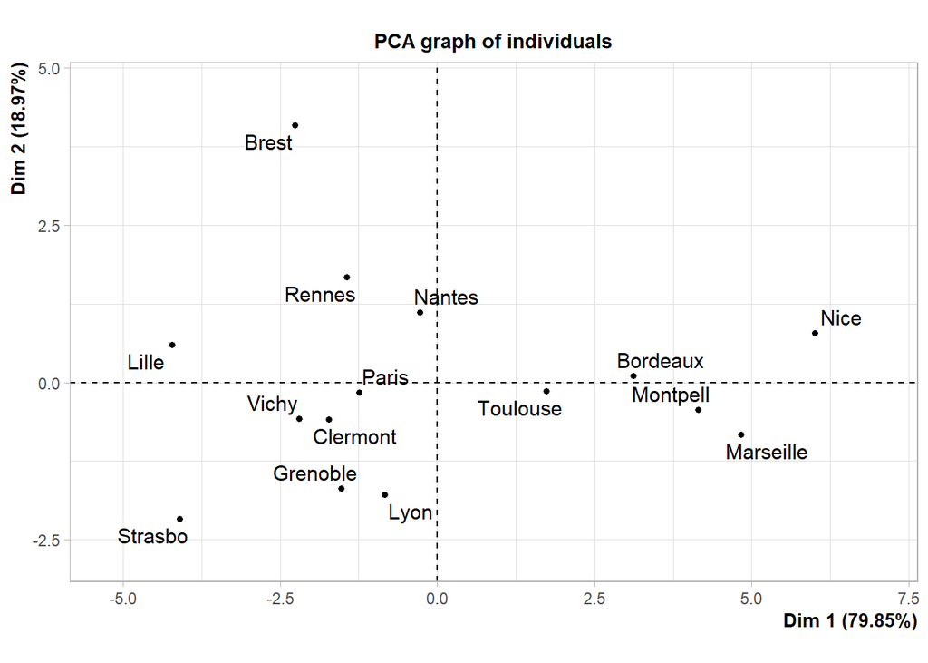

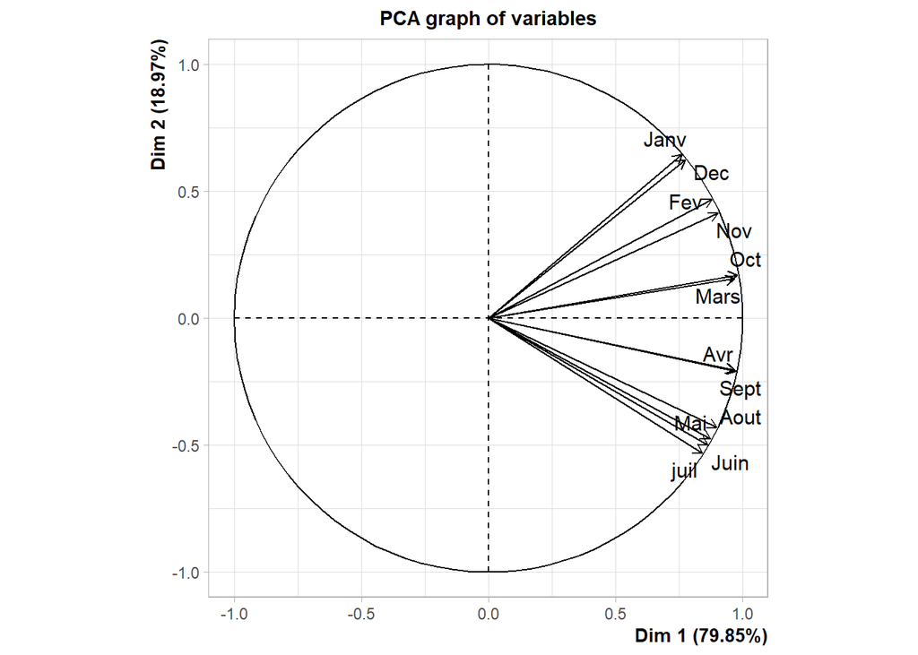

```
##          Dim.1      Dim.2
## Janv 0.5794838 0.41517130
## Fev  0.7752059 0.22003470
## Mars 0.9385160 0.02433862
## Avr  0.9396117 0.04148299
## Mai  0.7617180 0.22534881
## Juin 0.7457613 0.24934646
## juil 0.7081804 0.28240688
## Aout 0.8074926 0.18484719
## Sept 0.9487322 0.04330619
## Oct  0.9607134 0.02905542
## Nov  0.8167697 0.17133472
## Dec  0.5995945 0.38974512
```

-Suivant l’axe 1: Fevrier, Mars,Avril, Mai ,Juin, Juillet, Aout, Septembre, Octobre et Novembre sont **fortement positivement** correlles.

Donc l’interpretation se portera uniquementt sur l’axe 1.

**- Cas des individus** A la question precedente on avais vue que suivant **l’axe 1** **Nice,Marseille,Lille,Montpellier,Strasbourg et Bordeaux** avaient des contributions fortement superieure a la moyenne donc on va les retenire pour notre interpretation.

L’axe 1 oppose donc **Lille et Strasbourg** aux villes **Nice,Marseille,Montpellier et Bordeaux**

**Interpretation globale :**

En **Fevrier, Mars,Avril, Mai ,Juin, Juillet, Aout, Septembre, Octobre et Novembre** il fait beaucoup plus froid a **Lille et Strasbourg** parcontre dans les villes comme **Nice,Marseille,Montpellier et Bordeaux** fait beaucoup plus chaud.